# Introduction to Shiny

Session 2: *Shiny UI - layout, styling and theming*

Danny Smith

# Housekeeping

## Course outline

1. Introduction to Shiny
2. *Shiny UI - layout, styling and theming*
3. Shiny UI - dynamic UI and extensions
4. Reactivity and the user session
5. Application structure and workflow
6. Data ingress and egress

## Recap

### Last Session

1. *Introduction to Shiny*
- Homework
- Readings
- Questions?

## Resources

#### Session materials

[GitHub repo](https://github.com/gorcha/r_shiny_intro_data)

#### Online resources

[Outstanding User Interfaces with Shiny](https://unleash-shiny.rinterface.com/)

[Mozilla Developer Network: Learn web development](https://developer.mozilla.org/en-US/docs/Learn)

## This session

- How does Shiny UI work?
- Intro to Bootstrap
- Styling
- Layout
- Theming
- Beyond Bootstrap

# How does Shiny UI work?

## intro_app

```r
shiny::runApp("session_02/intro_app")
```

- ui.R
- server.R

```r
ui <- fluidPage(
  titlePanel("Miles Per Gallon"),

  sidebarLayout(
    sidebarPanel(
      selectInput(
        "variable",
        "Variable:",
        c("Cylinders" = "cyl", "Transmission" = "am", "Gears" = "gear")
      ),
      p("Simple text with a ", a("hyperlink", href = "#")),

      checkboxInput("outliers", "Show outliers", TRUE)
    ),

    mainPanel(
      h3(textOutput("caption")),
      plotOutput("mpg_plot")
    )
  )
)
```

```r
mpg_data <- mtcars
mpg_data$am <- factor(mpg_data$am, labels = c("Automatic", "Manual"))

server <- function(input, output, session) {
  formula_text <- reactive({
    paste("mpg ~", input$variable)
  })

  output$caption <- renderText({
    formula_text()
  })

  output$mpg_plot <- renderPlot({
    boxplot(
      as.formula(formula_text()),
      data = mpg_data,
      outline = input$outliers,
      col = "#75AADB",
      pch = 19
    )
  })
}
```

## Shiny in the browser

- `ui` function generates HTML `<body>`
- `<head>` includes js scripts and CSS files:
  - UI libraries
  - Styling - Bootstrap
  - Server interaction

```html
<!DOCTYPE html>
<html>
<head>
  <meta http-equiv="Content-Type" content="text/html; charset=utf-8"/>
  <script type="application/shiny-singletons"></script>
  <script type="application/html-dependencies">jquery[3.6.0];shiny-css[1.7.2];shiny-javascript[1.7.2];selectize[0.12.4];bootstrap[3.4.1]</script>
<script src="jquery-3.6.0/jquery.min.js"></script>
<link href="shiny-css-1.7.2/shiny.min.css" rel="stylesheet" />
<script src="shiny-javascript-1.7.2/shiny.min.js"></script>
<link href="selectize-0.12.4/css/selectize.bootstrap3.css" rel="stylesheet" />
<script src="selectize-0.12.4/js/selectize.min.js"></script>
<script src="selectize-0.12.4/accessibility/js/selectize-plugin-a11y.min.js"></script>
<meta name="viewport" content="width=device-width, initial-scale=1" />
<link href="bootstrap-3.4.1/css/bootstrap.min.css" rel="stylesheet" />
<link href="bootstrap-3.4.1/accessibility/css/bootstrap-accessibility.min.css" rel="stylesheet" />
<script src="bootstrap-3.4.1/js/bootstrap.min.js"></script>
<script src="bootstrap-3.4.1/accessibility/js/bootstrap-accessibility.min.js"></script>  <title>Miles Per Gallon</title>
</head>
<body>
  <div class="container-fluid">
    <h2>Miles Per Gallon</h2>
    <div class="row">
      <div class="col-sm-4">
        <form class="well" role="complementary">
          <div class="form-group shiny-input-container">
            <label class="control-label" id="variable-label" for="variable">Variable:</label>
            <div>
              <select id="variable"><option value="cyl" selected>Cylinders</option>
<option value="am">Transmission</option>
<option value="gear">Gears</option></select>
              <script type="application/json" data-for="variable" data-nonempty="">{"plugins":["selectize-plugin-a11y"]}</script>
            </div>
          </div>
          <p>
            Simple text with a
            <a href="#">hyperlink</a>
          </p>
          <div class="form-group shiny-input-container">
            <div class="checkbox">
              <label>
                <input id="outliers" type="checkbox" checked="checked"/>
                <span>Show outliers</span>
              </label>
            </div>
          </div>
        </form>
      </div>
      <div class="col-sm-8" role="main">
        <h3>
          <div id="caption" class="shiny-text-output"></div>
        </h3>
        <div id="mpg_plot" class="shiny-plot-output" style="width:100%;height:400px;"></div>
      </div>
    </div>
  </div>
</body>
</html>
```

## Shiny UI as HTML

All UI functions are essentially just HTML generators!

- Input, output and layout functions produce HTML
- Abstraction layer over underlying HTML

  ```r
  print(textInput("text", "My text"))
  ```

  ```
  <div class="form-group shiny-input-container">
    <label class="control-label" id="text-label" for="text">My text</label>
    <input id="text" type="text" class="form-control" value=""/>
  </div>
  ```

  - A single UI element may be made up of multiple HTML tags
  - Functions customise HTML appropriately
- Create an HTML UI without stepping out of R

## HTML generators

📦 [htmltools](https://rstudio.github.io/htmltools/) - tools for HTML in R

- Functions create HTML tags
  - Named arguments - attributes
  - Unnamed arguments - children
- Re-exported by Shiny
- Test appearance with `htmltools::browsable()`
- [Shiny HTML Tags Glossary](https://shiny.rstudio.com/articles/tag-glossary.html)
- R
- HTML

```r
tagList(
  tags$head(
    tags$title("My first page")
  ),
  tags$body(
    h1("My first heading"),
    p("My first paragraph, with some ", strong("bold"), " text."),
    div(
      id = "myDiv", class = "simpleDiv",
      "Here is a div with some attributes."
     )
  )
)
```

```html
<!DOCTYPE html>
<html lang="en">
<head>
<meta charset="utf-8"/>
<style>body{background-color:white;}</style>

  <title>My first page</title>
</head>
<body>
  <h1>My first heading</h1>
  <p>
    My first paragraph, with some
    <strong>bold</strong>
     text.
  </p>
  <div id="myDiv" class="simpleDiv">Here is a div with some attributes.</div>
</body>
</html>
```

📝 session_02/htmltools_intro.R

## Literal HTML

Use `HTML()` function to include literal HTML strings

- Include arbitrary blocks of HTML
- Rarely needed - most things are easier to achieve using HTML generators
- R
- HTML

```r
HTML(r"(
  <h1>This is a heading</h1>
  <p class="my-class">This is some text!</p>
  <ul>
    <li>First bullet</li>
    <li>Second bullet</li>
  </ul>
)")
```

```html
<h1>This is a heading</h1>
<p class="my-class">This is some text!</p>
<ul>
  <li>First bullet</li>
  <li>Second bullet</li>
</ul>
```

# Intro to Bootstrap

## Styling HTML

Unstyled HTML is ugly and limited UI components are available

Modern web applications use CSS and JavaScript for styling and UI functionality

- Many applications use a *UI framework* for layout, styling and UI components
- Shiny uses **Bootstrap**

## What is Bootstrap?

🌐 https://getbootstrap.com/

- Frontend web development framework
- JavaScript and CSS library
- Layout is *responsive*

Multiple versions with different styling and options

- Shiny uses [version 3](https://getbootstrap.com/docs/3.4/) by default for backwards compatibility
- Configure version with 📦 [bslib](https://rstudio.github.io/bslib/)
- We will use version **5**

```r
fluidPage(
  theme = bslib::bs_theme(version = 5),
  ...
)
```

## Bootstrap features

**Responsive layout - the grid system**

Simple grid-based layout system using rows and columns. Responsive to changes in screen size.

**UI components**

Additional UI components for building user interfaces, for e.g. Buttons, Tabsets, Progress bars.

**Styling**

Styling of all standard HTML elements and components, and utility classes to apply additional styling.

# Styling

## Bootstrap basics

🌐 [Bootstrap docs](https://getbootstrap.com/docs/5.2/getting-started/introduction/)

Bootstrap provides CSS classes that add styling and behaviour to HTML

```html
<div class="alert alert-primary" role="alert">
  A simple primary alert—check it out!
</div>
```

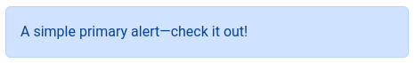

```r
div(
  class = "alert alert-primary",
  role = "alert",
  "A simple primary alert—check it out!"
)
```

Shiny HTML generators can include Bootstrap features by using named arguments to specify class and other attributes

## Bootstrap components

- Shiny UI functions create Bootstrap components, adding required attributes in the generated HTML
- Some Bootstrap components require more complex HTML structures

🌐 [Bootstrap docs](https://getbootstrap.com/docs/5.2/components/buttons/)

```r
actionButton("my_button", "Click me!")
```

```html
<button id="my_button" type="button" class="btn btn-default action-button">Click me!</button>
```

🌐 [Bootstrap docs](https://getbootstrap.com/docs/5.2/forms/checks-radios/)

```r
checkboxInput("my_checkbox", "Check me!")
```

```html
<div class="form-group shiny-input-container">
  <div class="checkbox">
    <label>
      <input id="my_checkbox" type="checkbox"/>
      <span>Check me!</span>
    </label>
  </div>
</div>
```

## Styling components - Buttons

🌐 [Bootstrap docs](https://getbootstrap.com/docs/5.2/components/buttons/)

- Add styling to Shiny UI elements using Bootstrap classes
- Only available in some functions
- Check out the help page!

```r
print(
  actionButton(
    "my_button",
    "Success!",
    class = "btn-success"
  )
)
```

```
<button class="btn btn-default action-button btn-success" id="my_button" type="button">Success!</button>
```

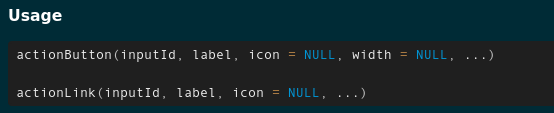

📝 session_02/bootstrap_styling.R

## Styling containers - Button groups

🌐 [Bootstrap docs](https://getbootstrap.com/docs/5.2/components/button-group/)

- Use classed `div()`s to add container styling
- Add additional attributes (`role`, `data-*`) as needed
- Make your own wrapper functions!

```r
buttonGroup <- function(..., class = "") {
  div(
    class = paste("btn-group", class),
    role = "group",
    ...
  )
}

print(
  buttonGroup(
    class = "btn-group-lg",
    actionButton("yes_button", "Yes", class = "btn-success"),
    actionButton("no_button", "No", class = "btn-danger")
  )
)
```

```
<div class="btn-group btn-group-lg" role="group">
  <button class="btn btn-default action-button btn-success" id="yes_button" type="button">Yes</button>
  <button class="btn btn-default action-button btn-danger" id="no_button" type="button">No</button>
</div>
```

📝 session_02/bootstrap_styling.R

## Creating components

🌐 [Bootstrap docs](https://getbootstrap.com/docs/5.2/components/alerts/#dismissing)

- Create components from scratch using htmltools functions
- Make your own wrapper functions!
- Lots of components available - see the docs for examples

```r
alert <- function(..., class = "") {
  div(
    class = paste("alert alert-dismissible fade show", class),
    role = "alert",
    ...,
    tags$button(
      type = "button",
      class = "btn-close",
      `data-bs-dismiss` = "alert",
      `aria-label` = "Close"
    )
  )
}

print(
  alert(class = "alert-warning", "Something needs your attention!")
)
```

```
<div class="alert alert-dismissible fade show alert-warning" role="alert">
  Something needs your attention!
  <button type="button" class="btn-close" data-bs-dismiss="alert" aria-label="Close"></button>
</div>
```

📝 session_02/bootstrap_styling.R

## Styling static content

Many styling options available…

- [Typography](https://getbootstrap.com/docs/5.2/content/typography/)
- [Text](https://getbootstrap.com/docs/5.2/utilities/text/)
- [Colors](https://getbootstrap.com/docs/5.2/utilities/colors/)

The documentation is great, have a read through for examples.

```r
print(
  tagList(
    h1(class = "display-3 text-center", "Bootstrap styling"),
    p(class = "lead text-center", "Some stylish examples"),
  )
)
```

```
<h1 class="display-3 text-center">Bootstrap styling</h1>
<p class="lead text-center">Some stylish examples</p>
```

📝 session_02/bootstrap_styling.R

# Layout

## Pages

Page function sets up HTML, CSS, and JavaScript and determines basic layout for the page

- `fluidPage()` - fills the full width of the browser
- `fixedPage()` - limit maximum width based on display size
- `fillPage()` - fills the browser with no padding

[figure not shown]

[figure not shown]

[figure not shown]

📝 session_02/pages.R

## Shiny layouts

Shiny provides some basic layouts - all are built on the Bootstrap grid

- Bootstrap grid layout
  - `*Row()`
  - `column()`
- Segmenting layouts
  - `navbarPage()`
  - `tabsetPanel()`
  - `navlistPanel()`
- Pre-built layouts
  - `sidebarLayout()`

[Shiny Application Layout Guide](https://shiny.rstudio.com/articles/layout-guide.html)

## Grid layout

Bootstrap layout is a *grid* made up of *rows* containing *columns*.

#### Rows

- `fluidRow()`/`fixedRow()`
- `fillRow()`

#### Columns

- `column()`
- Total width adds up to 12
- Can be nested

```r
ui <- fixedPage(
  theme = bslib::bs_theme(version = 5),
  fixedRow(
    column(4, "1 of 3"),
    column(4, "2 of 3"),
    column(4, "3 of 3")
  ),
  fixedRow(
    column(4,
      fixedRow(
        column(6, "1 of 2"),
        column(6, "2 of 2")
      )
    ),
    column(8,
      fixedRow(
        column(12, "1 of 1")
      )
    )
  )
)
```

📝 session_02/bootstrap_grid.R

## Layout utilities

Bootstrap utility classes can be used for layout elements

- [Spacing](https://getbootstrap.com/docs/5.2/utilities/spacing/)
  - Add margins and padding to containers and UI components
- [Colors](https://getbootstrap.com/docs/5.2/utilities/borders/)
- [Borders](https://getbootstrap.com/docs/5.2/utilities/borders/)

```r
ui <- fluidPage(
  theme = bslib::bs_theme(version = 5),
  class = "bg-secondary",
  fixedRow(
    column(4, class = "p-2 bg-info border", "1 of 3"),
    column(4, class = "p-2 bg-light border", "2 of 3"),
    column(4, class = "p-2 bg-warning border", "3 of 3")
  )
)
```

## Segmenting layouts

Segmenting layouts break your application into selectable pages of content

- `tabsetPanel()`, `navlistPanel()`
- `tabPanel()` for each page
- Place inside an existing layout

#### Multi-page layouts

- `navbarPage()`
- Top-level pages of content

```r
ui <- fixedPage(
  theme = bslib::bs_theme(version = 5),
  h1("Tabs!"),

  tabsetPanel(
    tabPanel(
      "Plot",
      plotOutput("my_plot")
    ),
    tabPanel(
      "Table",
      tableOutput("my_table")
    )
  )
)
```

📝 session_02/segmenting_layout.R

## Pre-built layouts

Shiny provides some simple pre-built layouts and panels

#### Layout and panels

- `titlePanel()`
- `sideBarLayout()`, `sidebarPanel()`, `mainPanel()`

#### Extension packages

- Limited layouts available in Shiny

```r
ui <- fluidPage(
  theme = bslib::bs_theme(version = 5),
  titlePanel("Miles Per Gallon"),

  sidebarLayout(
    sidebarPanel(
      checkboxInput("outliers", "Show outliers", TRUE)
    ),

    mainPanel(
      h3(textOutput("caption")),
      plotOutput("mpg_plot")
    )
  )
)
```

📁 session_02/intro_app

# Theming

## Bootstrap themes

📦 [bslib](https://rstudio.github.io/bslib/) - customise Bootstrap styling defaults

- Create a theme with `bslib::bs_theme()`
- Specify `theme` in the page function

```r
library(shiny)
library(bslib)

ui <- fluidPage(
  theme = bs_theme(
    version = 5,
    bg = "#101010",
    fg = "#FDF7F7",
    primary = "#ED79F9",
    base_font = font_google("Prompt"),
    "progress-bar-bg" = "orange"
  ),
  ...
)
```

Set the Bootstrap version

```r
bs_theme(version = 5)
```

Use a [Bootswatch](https://bootswatch.com/) theme

```r
bs_theme(bootswatch = ...)
```

Test theme changes interactively

```r
bs_theme_preview(theme)
run_with_themer(appDir)
```

## Plot themes

📦 [thematic](https://rstudio.github.io/thematic/) - apply bslib theme to plots produced by gplot, lattice or base R

- Use the current Bootstrap theme in plots
- Call `thematic_shiny()` to automatically apply styling to graphics

```r
# Example from https://rstudio.github.io/thematic/
library(shiny)
library(ggplot2)
library(thematic)

# Call thematic_shiny() prior to launching the app, to change
# R plot theming defaults for all the plots generated in the app
thematic_shiny(font = "auto")

ui <- fluidPage(
  # bslib makes it easy to customize CSS styles for things
  # rendered by the browser, like tabsetPanel()
  # https://rstudio.github.io/bslib
  theme = bslib::bs_theme(
    bg = "#002B36", fg = "#EEE8D5", primary = "#2AA198",
    # bslib also makes it easy to import CSS fonts
    base_font = bslib::font_google("Pacifico")
  ),
  tabsetPanel(
    type = "pills",
    tabPanel("ggplot", plotOutput("ggplot")),
    tabPanel("lattice", plotOutput("lattice")),
    tabPanel("base", plotOutput("base"))
  )
)

server <- function(input, output) {
  output$ggplot <- renderPlot({
    ggplot(mtcars, aes(wt, mpg, label = rownames(mtcars), color = factor(cyl))) +
      geom_point() +
      ggrepel::geom_text_repel()
  })
  output$lattice <- renderPlot({
    lattice::show.settings()
  })
  output$base <- renderPlot({
    image(volcano, col = thematic_get_option("sequential"))
  })
}

shinyApp(ui, server)
```

📝 session_02/thematic.R

# Beyond Bootstrap

## Other styling libraries

Alternative functions to build layouts and additional UI components

📦 [shinydashboard](https://rstudio.github.io/shinydashboard/)

```
app.R
```

```r
library(shiny)
library(shinydashboard)

ui <- dashboardPage(
  dashboardHeader(),
  dashboardSidebar(),
  dashboardBody()
)

server <- function(input, output, session) {
}

shinyApp(ui, server)
```

**🌐 [RinteRface](https://rinterface.com/#packages)**

Collection of packages providing HTML templates and alternative styling libraries

**🌐 [Appsilon Shiny Tools](https://shiny.tools/)**

A set of Shiny utility packages, including some styling and layout alternatives

**🌐 [Awesome Shiny Extensions](https://github.com/nanxstats/awesome-shiny-extensions#theming)**

Almost exhaustive list of Shiny related packages - see “Theming”

## Custom CSS

#### www sub-directory

- Contains resources your app may link to, such as images or scripts
- File name in R is relative to www

#### Include scripts

- Use a `link()` tag with `head()` to load a stylesheet

🌐 [Shiny docs](https://shiny.rstudio.com/articles/css.html)

```
shinyapp
├── www
│   └── custom.css
├── server.R
└── ui.R
```

```r
shiny::runApp("shinyapp")
```

```
ui.R
```

```r
ui <- fluidPage(
  tags$head(
    tags$link(rel = "stylesheet", type = "text/css", href = "custom.css")
  ),
  div(class = "red-div", "Red background")
)
```

```
custom.css
```

```css
.red-div {
  background-color: red;
}
```

📁 session_02/custom_css

# Wrapping up

## Homework - Readings

### Mastering Shiny

**[Chapter 6: Layout, themes, HTML](https://mastering-shiny.org/action-layout.html)**

### Shiny articles

**[Customize your UI with HTML](https://shiny.rstudio.com/articles/html-tags.html)**

**[Application Layout Guide](https://shiny.rstudio.com/articles/layout-guide.html)**

### Mozilla Developer Network

**[HTML basics](https://developer.mozilla.org/en-US/docs/Learn/Getting_started_with_the_web/HTML_basics)**

**[CSS basics](https://developer.mozilla.org/en-US/docs/Learn/Getting_started_with_the_web/CSS_basics)**

**[JavaScript basics](https://developer.mozilla.org/en-US/docs/Learn/Getting_started_with_the_web/JavaScript_basics)**

## Homework - Exercise

Style your Shiny application from session 1

- Use the Bootstrap grid
- Segment your layout with a tabset or navlist
- Add some styled components
  - Can be static or Shiny UI
  - Style a button
- Apply a theme with bslib
  - `bslib::bs_theme_preview()` for ideas
- Use thematic to apply the bslib theme to a plot
  - Add a plot if you don’t already have one ;)

## Goodbye!

### Next Session

3. *Shiny UI - dynamic UI and extensions*

**Introduction to Shiny** Session 2: *Shiny UI - layout, styling and theming*